# Introduction

The good old conventional fully connected forward feeding neural network:

[figure not shown]

It has permutation symmetries in the hidden layers!

If we optimize the model's joint likelihood or loss, we find that extrema in the parameter space are factorially replicated by these symmetries. So the parameter space contains numerous functionally identical modes.

Is that bad? If nothing else, it confuses model identifiability, and makes it harder to build an ensemble of genuinely different models. I claim that mode symmetries also hinder bayesian monte carlo techniques and that it is beneficial to eliminate them. In the literature one finds examples of symmetry breaking by neuron bias ordering and by the addition of skip connections. In the following, we'll study a novel technique for ordering neurons within a layer by the (L2) magnitude of the weight vector.

A simple HMC/NUTS experiment on a regression model with 2 hidden layers of varying size showed a gain in predictive performance if the neurons were ordered in this way, as measured by RMSE and compared to a conventional model. The task was the Boston Housing benchmark dataset – prediction of sale prices based on real property features. Other typical assessments of MCMC performance (effective sample size, R-hat) were not so clearly interpretable, but did not seem to change much.

# Methodology

The NN architecture was exactly as pictured above, except for the number of input features and the hidden layer sizes. The input layer was of course matched to the dataset, with every train/test split normalized to zero mean and unit variance over the training data. The hidden layers were ReLU activated and sized at 60, 120, 180, or 240, with both layers always the same size.

The experiment was to run HMC/NUTS bayesian inference on these architectures, with an IID normal prior on all weights and biases, and repetition over probability models with and without symmetry breaking. All models used a single shared precision parameter for the prior, and assumed a normal distribution on the output, with its own precision parameter. Both precisions were drawn from gamma distributions. Warmup and sample sizes were kept equal, taking values of 100, 200, or 400. The models and experiment were implemented with python and numpyro.

Four models were actually investigated, as follows (for lack of better names):

| Model name | Symmetry breaking |
| --- | --- |
| Reference | no |
| Improper | yes |
| Dumb | no |
| Efficient | yes |

## Reference model

This model is the benchmark for comparison. Weights and biases are "drawn" IID from a normal distribution centered on zero.

## Improper model

This model adds symmetry breaking to the reference model in a basic way. The name comes from the use of numpyro's [ImproperUniform](https://num.pyro.ai/en/stable/distributions.html#improperuniform) distribution.

So how do you get rid of permutation symmetries? By transforming the parameter space, naturally. If no transformation is made, the parameter space is effectively a high-dimensional Euclidean space $W$ where points are models and we run inference based on the probability density calculated at visited points.

What we can do is run inference on a new Euclidean space $V$, with a mapping from $V$ to the space of model parameters $W$, where the prior is defined. The image of the mapping should contain all functionally distinct models, but no two models related by permutation symmetry. Taking the L2 norm of the weight vector of every neuron in a layer, one solution is to guarantee these norms are monotonically ordered (as per the positional indices of neurons).

Let $w_{i,j}$ denote the weight vector of the $i$-th neuron in the $j$-th layer, such that any point in $W$ is composed of these $w_{i,j}$ plus biases $b_{i,j}$. I define $V$ with an identity mapping for biases and components $v_{i,j}$ for every $w_{i,j}$ such that

\begin{align} \dim v_{i,j} &= \dim w_{i,j} \\ \lVert w_{i,j} \rVert ^2 &= \sum_{k \le i} \lVert v_{k,j} \rVert ^2 \end{align}

Operationally, during inference these $v_{i,j}$ come from an "improper uniform" distribution; no probability density factor is contributed and they are merely constrained to be vectors of real numbers. Dropping the layer subscript for brevity, we then have $w_1 = v_1$, and for $w_2$, we copy the angle of $v_2$ but send the magnitude to $\sqrt{\lVert v_1 \rVert ^2 + \lVert v_2 \rVert ^2}$. Repeating the formula we get all $w_i$ for each layer iteratively, and from the $w_i$ the prior density factor is computed.

Symmetry breaking is achieved because no two neurons can switch places, unless they have precisely the same L2 norm. This exception will occur with vanishing probability and it can be ignored ("almost sure" symmetry breaking).

The purpose of this model is to show that symmetry breaking has a beneficial effect, with a minimal departure from the reference model. There are inefficiencies in the code which are addressed in the "efficient" model.

## Dumb model

This model reproduces the reference model, but instead of sampling a normal distribution for the weights and biases as in the reference model, it follows the implementation of the "improper" model by using the improper uniform for weights and biases and then adding probability factors according to the normal prior. The reason for this is to control for numerical side effects of the different coding techniques which might affect the results but have nothing to do with the math.

## Efficient model

This model is the "improper" model with a few code optimizations.

# Results

4 hidden layer sizes (60, 120, 180, 240) and 3 posterior sample sizes (100, 200, 400) gives 12 distinct experiments, in which train/test splits were chosen randomly and the 4 models were scored by RMSE on the test data.

A model's RMSE is a random variable depending on the train/test split and the HMC/NUTS process. So any one of the models could outperform the others given a lucky random seed. Hence 50 random seeds were used and we are looking at samples of 50 RMSE observations per model. More than 50 would have been ideal, but even relatively small experiments like these require a lot of compute time.

Without further ado, here's how they stacked up:

100 samples

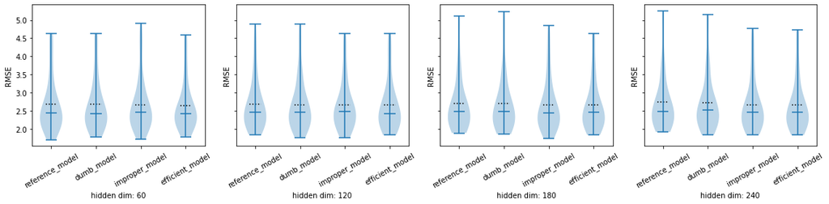

200 samples

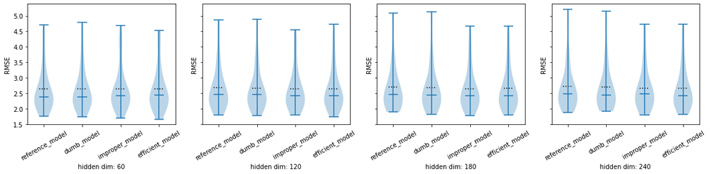

400 samples

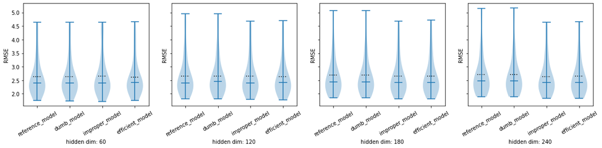

## Discussion

So hopefully it's clear now that on average, and proportionate to model complexity, RMSE is improved by the above technique. Of course this experiment was based on a toy dataset and it remains to be seen what might happen with other datasets and bigger models.

It may be interesting to look at diagnostics such as effective sample size and R-hat. The following notebooks contain plots for those, and some additional characterizations of model behavior which remain to be discussed:

- 100 samples
- 200 samples
- 400 samples